# Risk Factor Analysis

## Outcome Variable

**Outcome Variable:** haz

## Predictor Variables

**Intervention Variable:** pers_wast

**Adjustment Set:**

- arm
- sex
- brthmon
- W_mage
- meducyrs
- hhwealth_quart
- W_nrooms
- month
- impfloor
- delta_W_mage
- delta_meducyrs
- delta_hhwealth_quart
- delta_W_nrooms
- delta_month
- delta_impfloor

## Stratifying Variables

The analysis was stratified on these variable(s):

- agecat
- studyid
- country

## Data Summary

| agecat | studyid | country | pers_wast | n_cell | n |
| --- | --- | --- | --- | --- | --- |
| Birth | ki0047075b-MAL-ED | BANGLADESH | 0 | 220 | 229 |
| Birth | ki0047075b-MAL-ED | BANGLADESH | 1 | 9 | 229 |
| Birth | ki0047075b-MAL-ED | BRAZIL | 0 | 65 | 65 |
| Birth | ki0047075b-MAL-ED | BRAZIL | 1 | 0 | 65 |
| Birth | ki0047075b-MAL-ED | INDIA | 0 | 43 | 45 |
| Birth | ki0047075b-MAL-ED | INDIA | 1 | 2 | 45 |
| Birth | ki0047075b-MAL-ED | NEPAL | 0 | 26 | 27 |
| Birth | ki0047075b-MAL-ED | NEPAL | 1 | 1 | 27 |
| Birth | ki0047075b-MAL-ED | PERU | 0 | 233 | 233 |
| Birth | ki0047075b-MAL-ED | PERU | 1 | 0 | 233 |
| Birth | ki0047075b-MAL-ED | SOUTH AFRICA | 0 | 111 | 113 |
| Birth | ki0047075b-MAL-ED | SOUTH AFRICA | 1 | 2 | 113 |
| Birth | ki0047075b-MAL-ED | TANZANIA, UNITED REPUBLIC OF | 0 | 123 | 123 |
| Birth | ki0047075b-MAL-ED | TANZANIA, UNITED REPUBLIC OF | 1 | 0 | 123 |
| Birth | ki1000108-CMC-V-BCS-2002 | INDIA | 0 | 80 | 92 |
| Birth | ki1000108-CMC-V-BCS-2002 | INDIA | 1 | 12 | 92 |
| Birth | ki1000108-IRC | INDIA | 0 | 319 | 387 |
| Birth | ki1000108-IRC | INDIA | 1 | 68 | 387 |
| Birth | ki1000109-EE | PAKISTAN | 0 | 224 | 240 |
| Birth | ki1000109-EE | PAKISTAN | 1 | 16 | 240 |
| Birth | ki1000109-ResPak | PAKISTAN | 0 | 30 | 34 |
| Birth | ki1000109-ResPak | PAKISTAN | 1 | 4 | 34 |
| Birth | ki1017093b-PROVIDE | BANGLADESH | 0 | 516 | 539 |
| Birth | ki1017093b-PROVIDE | BANGLADESH | 1 | 23 | 539 |
| Birth | ki1101329-Keneba | GAMBIA | 0 | 12 | 13 |
| Birth | ki1101329-Keneba | GAMBIA | 1 | 1 | 13 |
| Birth | ki1113344-GMS-Nepal | NEPAL | 0 | 521 | 585 |
| Birth | ki1113344-GMS-Nepal | NEPAL | 1 | 64 | 585 |
| Birth | ki1114097-CMIN | BANGLADESH | 0 | 16 | 18 |
| Birth | ki1114097-CMIN | BANGLADESH | 1 | 2 | 18 |

[output cut: 70 more lines]

The following strata were considered:

- agecat: 24 months, studyid: ki0047075b-MAL-ED, country: BANGLADESH
- agecat: 24 months, studyid: ki0047075b-MAL-ED, country: BRAZIL
- agecat: 24 months, studyid: ki0047075b-MAL-ED, country: INDIA
- agecat: 24 months, studyid: ki0047075b-MAL-ED, country: NEPAL
- agecat: 24 months, studyid: ki0047075b-MAL-ED, country: PERU
- agecat: 24 months, studyid: ki0047075b-MAL-ED, country: SOUTH AFRICA
- agecat: 24 months, studyid: ki0047075b-MAL-ED, country: TANZANIA, UNITED REPUBLIC OF
- agecat: 24 months, studyid: ki1000108-CMC-V-BCS-2002, country: INDIA
- agecat: 24 months, studyid: ki1000108-IRC, country: INDIA
- agecat: 24 months, studyid: ki1000109-EE, country: PAKISTAN
- agecat: 24 months, studyid: ki1017093b-PROVIDE, country: BANGLADESH
- agecat: 24 months, studyid: ki1066203-TanzaniaChild2, country: TANZANIA, UNITED REPUBLIC OF
- agecat: 24 months, studyid: ki1101329-Keneba, country: GAMBIA
- agecat: 24 months, studyid: ki1113344-GMS-Nepal, country: NEPAL
- agecat: 24 months, studyid: ki1114097-CMIN, country: BANGLADESH
- agecat: 24 months, studyid: ki1114097-CONTENT, country: PERU
- agecat: 6 months, studyid: ki0047075b-MAL-ED, country: BANGLADESH
- agecat: 6 months, studyid: ki0047075b-MAL-ED, country: BRAZIL
- agecat: 6 months, studyid: ki0047075b-MAL-ED, country: INDIA
- agecat: 6 months, studyid: ki0047075b-MAL-ED, country: NEPAL
- agecat: 6 months, studyid: ki0047075b-MAL-ED, country: PERU
- agecat: 6 months, studyid: ki0047075b-MAL-ED, country: SOUTH AFRICA
- agecat: 6 months, studyid: ki0047075b-MAL-ED, country: TANZANIA, UNITED REPUBLIC OF
- agecat: 6 months, studyid: ki1000108-CMC-V-BCS-2002, country: INDIA
- agecat: 6 months, studyid: ki1000108-IRC, country: INDIA
- agecat: 6 months, studyid: ki1000109-EE, country: PAKISTAN
- agecat: 6 months, studyid: ki1000109-ResPak, country: PAKISTAN
- agecat: 6 months, studyid: ki1017093b-PROVIDE, country: BANGLADESH
- agecat: 6 months, studyid: ki1066203-TanzaniaChild2, country: TANZANIA, UNITED REPUBLIC OF
- agecat: 6 months, studyid: ki1101329-Keneba, country: GAMBIA
- agecat: 6 months, studyid: ki1112895-Guatemala BSC, country: GUATEMALA
- agecat: 6 months, studyid: ki1113344-GMS-Nepal, country: NEPAL
- agecat: 6 months, studyid: ki1114097-CMIN, country: BANGLADESH
- agecat: 6 months, studyid: ki1114097-CONTENT, country: PERU
- agecat: Birth, studyid: ki0047075b-MAL-ED, country: BANGLADESH
- agecat: Birth, studyid: ki0047075b-MAL-ED, country: BRAZIL
- agecat: Birth, studyid: ki0047075b-MAL-ED, country: INDIA
- agecat: Birth, studyid: ki0047075b-MAL-ED, country: NEPAL
- agecat: Birth, studyid: ki0047075b-MAL-ED, country: PERU
- agecat: Birth, studyid: ki0047075b-MAL-ED, country: SOUTH AFRICA
- agecat: Birth, studyid: ki0047075b-MAL-ED, country: TANZANIA, UNITED REPUBLIC OF
- agecat: Birth, studyid: ki1000108-CMC-V-BCS-2002, country: INDIA
- agecat: Birth, studyid: ki1000108-IRC, country: INDIA
- agecat: Birth, studyid: ki1000109-EE, country: PAKISTAN
- agecat: Birth, studyid: ki1000109-ResPak, country: PAKISTAN
- agecat: Birth, studyid: ki1017093b-PROVIDE, country: BANGLADESH
- agecat: Birth, studyid: ki1101329-Keneba, country: GAMBIA
- agecat: Birth, studyid: ki1113344-GMS-Nepal, country: NEPAL
- agecat: Birth, studyid: ki1114097-CMIN, country: BANGLADESH
- agecat: Birth, studyid: ki1114097-CONTENT, country: PERU

### Dropped Strata

Some strata were dropped due to rare outcomes:

- agecat: Birth, studyid: ki0047075b-MAL-ED, country: BRAZIL
- agecat: Birth, studyid: ki0047075b-MAL-ED, country: INDIA
- agecat: Birth, studyid: ki0047075b-MAL-ED, country: NEPAL
- agecat: Birth, studyid: ki0047075b-MAL-ED, country: PERU
- agecat: Birth, studyid: ki0047075b-MAL-ED, country: SOUTH AFRICA
- agecat: Birth, studyid: ki0047075b-MAL-ED, country: TANZANIA, UNITED REPUBLIC OF
- agecat: Birth, studyid: ki1000109-ResPak, country: PAKISTAN
- agecat: Birth, studyid: ki1101329-Keneba, country: GAMBIA
- agecat: Birth, studyid: ki1114097-CMIN, country: BANGLADESH
- agecat: Birth, studyid: ki1114097-CONTENT, country: PERU
- agecat: 6 months, studyid: ki0047075b-MAL-ED, country: BRAZIL
- agecat: 6 months, studyid: ki0047075b-MAL-ED, country: PERU
- agecat: 6 months, studyid: ki0047075b-MAL-ED, country: SOUTH AFRICA
- agecat: 6 months, studyid: ki0047075b-MAL-ED, country: TANZANIA, UNITED REPUBLIC OF
- agecat: 6 months, studyid: ki1114097-CONTENT, country: PERU
- agecat: 24 months, studyid: ki0047075b-MAL-ED, country: BRAZIL
- agecat: 24 months, studyid: ki0047075b-MAL-ED, country: PERU
- agecat: 24 months, studyid: ki0047075b-MAL-ED, country: SOUTH AFRICA
- agecat: 24 months, studyid: ki0047075b-MAL-ED, country: TANZANIA, UNITED REPUBLIC OF
- agecat: 24 months, studyid: ki1066203-TanzaniaChild2, country: TANZANIA, UNITED REPUBLIC OF
- agecat: 24 months, studyid: ki1114097-CONTENT, country: PERU

## Methods Detail

We’re interested in the causal parameters $E[Y_a]$ for all values of $a \in \mathcal{A}$. These parameters represent the mean outcome if, possibly contrary to fact, we intervened to set all units to have $A=a$. Under the randomization and positivity assumptions, these are identified by the statistical parameters $\psi_a=E_W[E_{Y|A,W}(Y|A=a,W)]$. In addition, we’re interested in the mean of $Y$, $E[Y]$ under no intervention (the observed mean). We will estimate these parameters by using SuperLearner to fit the relevant likelihood factors – $E_{Y|A,W}(Y|A=a,W)$ and $p(A=a|W)$, and then updating our likelihood fit using a joint TMLE.

For unadjusted analyses ($W=\{\}$), initial likelihoods were estimated using Lrnr_glm to estimate the simple $E(Y|A)$ and Lrnr_mean to estimate $p(A)$. For adjusted analyses, a small library containing Lrnr_glmnet, Lrnr_xgboost, and Lrnr_mean was used.

Having estimated these parameters, we will then use the delta method to estimate relative risks and attributable risks relative to a prespecified baseline level of $A$.

# Results Detail

## Results Plots

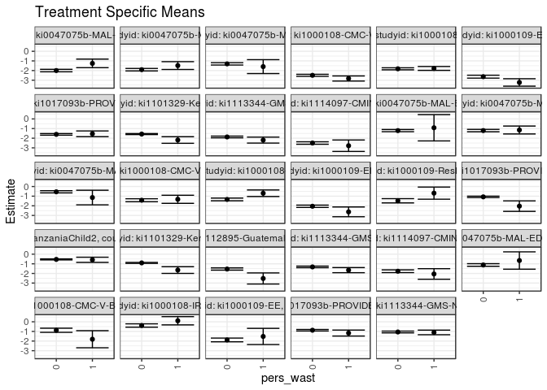

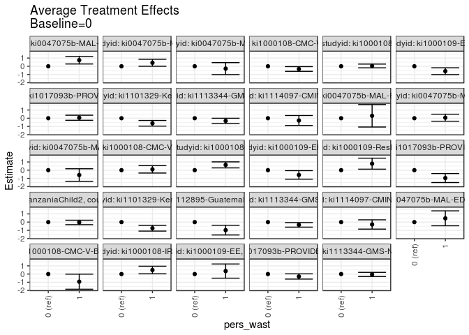

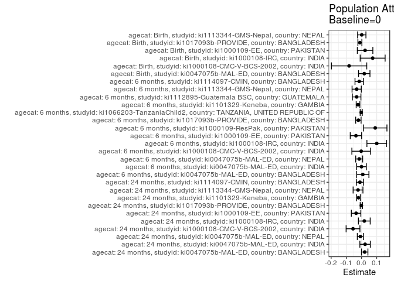

## Results Table

### Parameter: TSM

| agecat | studyid | country | intervention_level | baseline_level | estimate | ci_lower | ci_upper |
| --- | --- | --- | --- | --- | --- | --- | --- |
| Birth | ki0047075b-MAL-ED | BANGLADESH | 0 | NA | -1.1222727 | -1.2564846 | -0.9880609 |
| Birth | ki0047075b-MAL-ED | BANGLADESH | 1 | NA | -0.6600000 | -1.5592093 | 0.2392093 |
| Birth | ki1000108-CMC-V-BCS-2002 | INDIA | 0 | NA | -0.8795863 | -1.0941752 | -0.6649975 |
| Birth | ki1000108-CMC-V-BCS-2002 | INDIA | 1 | NA | -1.8098943 | -2.6961871 | -0.9236016 |
| Birth | ki1000108-IRC | INDIA | 0 | NA | -0.3852055 | -0.5573569 | -0.2130541 |
| Birth | ki1000108-IRC | INDIA | 1 | NA | 0.1067343 | -0.3223330 | 0.5358015 |
| Birth | ki1000109-EE | PAKISTAN | 0 | NA | -1.8844515 | -2.0784700 | -1.6904329 |
| Birth | ki1000109-EE | PAKISTAN | 1 | NA | -1.5202838 | -2.3589339 | -0.6816338 |
| Birth | ki1017093b-PROVIDE | BANGLADESH | 0 | NA | -0.8745720 | -0.9520159 | -0.7971281 |
| Birth | ki1017093b-PROVIDE | BANGLADESH | 1 | NA | -1.1688115 | -1.4788945 | -0.8587286 |
| Birth | ki1113344-GMS-Nepal | NEPAL | 0 | NA | -1.0571772 | -1.1491838 | -0.9651705 |
| Birth | ki1113344-GMS-Nepal | NEPAL | 1 | NA | -1.1027664 | -1.3398508 | -0.8656821 |
| 6 months | ki0047075b-MAL-ED | BANGLADESH | 0 | NA | -1.2140954 | -1.3277296 | -1.1004613 |
| 6 months | ki0047075b-MAL-ED | BANGLADESH | 1 | NA | -0.9178571 | -2.2823123 | 0.4465980 |
| 6 months | ki0047075b-MAL-ED | INDIA | 0 | NA | -1.2113480 | -1.3355490 | -1.0871470 |
| 6 months | ki0047075b-MAL-ED | INDIA | 1 | NA | -1.1500586 | -1.5595788 | -0.7405385 |
| 6 months | ki0047075b-MAL-ED | NEPAL | 0 | NA | -0.5459348 | -0.6592446 | -0.4326250 |
| 6 months | ki0047075b-MAL-ED | NEPAL | 1 | NA | -1.1408333 | -1.8980656 | -0.3836011 |
| 6 months | ki1000108-CMC-V-BCS-2002 | INDIA | 0 | NA | -1.4222375 | -1.5758616 | -1.2686135 |
| 6 months | ki1000108-CMC-V-BCS-2002 | INDIA | 1 | NA | -1.3224184 | -1.7436021 | -0.9012347 |
| 6 months | ki1000108-IRC | INDIA | 0 | NA | -1.3388261 | -1.4788381 | -1.1988141 |
| 6 months | ki1000108-IRC | INDIA | 1 | NA | -0.6946089 | -1.0350216 | -0.3541962 |
| 6 months | ki1000109-EE | PAKISTAN | 0 | NA | -2.0469201 | -2.1690268 | -1.9248133 |
| 6 months | ki1000109-EE | PAKISTAN | 1 | NA | -2.6272922 | -3.1353040 | -2.1192805 |
| 6 months | ki1000109-ResPak | PAKISTAN | 0 | NA | -1.4777726 | -1.6978957 | -1.2576496 |
| 6 months | ki1000109-ResPak | PAKISTAN | 1 | NA | -0.6850462 | -1.3146014 | -0.0554910 |
| 6 months | ki1017093b-PROVIDE | BANGLADESH | 0 | NA | -1.0712335 | -1.1457522 | -0.9967147 |
| 6 months | ki1017093b-PROVIDE | BANGLADESH | 1 | NA | -2.0308426 | -2.5738652 | -1.4878199 |
| 6 months | ki1066203-TanzaniaChild2 | TANZANIA, UNITED REPUBLIC OF | 0 | NA | -0.5432993 | -0.5932467 | -0.4933519 |
| 6 months | ki1066203-TanzaniaChild2 | TANZANIA, UNITED REPUBLIC OF | 1 | NA | -0.5843223 | -0.8520265 | -0.3166180 |
| 6 months | ki1101329-Keneba | GAMBIA | 0 | NA | -0.9053798 | -0.9542651 | -0.8564944 |
| 6 months | ki1101329-Keneba | GAMBIA | 1 | NA | -1.6479711 | -1.9945573 | -1.3013849 |
| 6 months | ki1112895-Guatemala BSC | GUATEMALA | 0 | NA | -1.5415418 | -1.6567941 | -1.4262896 |
| 6 months | ki1112895-Guatemala BSC | GUATEMALA | 1 | NA | -2.5211111 | -3.0985428 | -1.9436794 |
| 6 months | ki1113344-GMS-Nepal | NEPAL | 0 | NA | -1.3216164 | -1.4035428 | -1.2396899 |
| 6 months | ki1113344-GMS-Nepal | NEPAL | 1 | NA | -1.6574760 | -1.9225604 | -1.3923916 |
| 6 months | ki1114097-CMIN | BANGLADESH | 0 | NA | -1.7695312 | -1.9111078 | -1.6279545 |
| 6 months | ki1114097-CMIN | BANGLADESH | 1 | NA | -2.0554572 | -2.6034929 | -1.5074214 |
| 24 months | ki0047075b-MAL-ED | BANGLADESH | 0 | NA | -1.9999757 | -2.1284968 | -1.8714547 |
| 24 months | ki0047075b-MAL-ED | BANGLADESH | 1 | NA | -1.2558333 | -1.7012482 | -0.8104185 |
| 24 months | ki0047075b-MAL-ED | INDIA | 0 | NA | -1.9085214 | -2.0396123 | -1.7774305 |
| 24 months | ki0047075b-MAL-ED | INDIA | 1 | NA | -1.4822170 | -1.8857759 | -1.0786580 |
| 24 months | ki0047075b-MAL-ED | NEPAL | 0 | NA | -1.3043468 | -1.4255244 | -1.1831693 |
| 24 months | ki0047075b-MAL-ED | NEPAL | 1 | NA | -1.5900000 | -2.3102086 | -0.8697914 |
| 24 months | ki1000108-CMC-V-BCS-2002 | INDIA | 0 | NA | -2.4930855 | -2.5982097 | -2.3879613 |
| 24 months | ki1000108-CMC-V-BCS-2002 | INDIA | 1 | NA | -2.8236332 | -3.0895539 | -2.5577125 |
| 24 months | ki1000108-IRC | INDIA | 0 | NA | -1.8174188 | -1.9225733 | -1.7122643 |
| 24 months | ki1000108-IRC | INDIA | 1 | NA | -1.7775435 | -1.9795956 | -1.5754913 |
| 24 months | ki1000109-EE | PAKISTAN | 0 | NA | -2.6343538 | -2.7853738 | -2.4833338 |
| 24 months | ki1000109-EE | PAKISTAN | 1 | NA | -3.2338954 | -3.6201742 | -2.8476166 |
| 24 months | ki1017093b-PROVIDE | BANGLADESH | 0 | NA | -1.6015808 | -1.6866968 | -1.5164647 |
| 24 months | ki1017093b-PROVIDE | BANGLADESH | 1 | NA | -1.5437364 | -1.8408624 | -1.2466105 |
| 24 months | ki1101329-Keneba | GAMBIA | 0 | NA | -1.5722533 | -1.6264470 | -1.5180596 |
| 24 months | ki1101329-Keneba | GAMBIA | 1 | NA | -2.1887296 | -2.5302016 | -1.8472575 |
| 24 months | ki1113344-GMS-Nepal | NEPAL | 0 | NA | -1.8709624 | -1.9598555 | -1.7820692 |
| 24 months | ki1113344-GMS-Nepal | NEPAL | 1 | NA | -2.1969626 | -2.5051803 | -1.8887448 |
| 24 months | ki1114097-CMIN | BANGLADESH | 0 | NA | -2.5005794 | -2.6283894 | -2.3727694 |
| 24 months | ki1114097-CMIN | BANGLADESH | 1 | NA | -2.7794444 | -3.3734067 | -2.1854822 |

### Parameter: E(Y)

| agecat | studyid | country | intervention_level | baseline_level | estimate | ci_lower | ci_upper |
| --- | --- | --- | --- | --- | --- | --- | --- |
| Birth | ki0047075b-MAL-ED | BANGLADESH | NA | NA | -1.1041048 | -1.2383048 | -0.9699048 |
| Birth | ki1000108-CMC-V-BCS-2002 | INDIA | NA | NA | -0.9611957 | -1.1776967 | -0.7446946 |
| Birth | ki1000108-IRC | INDIA | NA | NA | -0.3117313 | -0.4727359 | -0.1507267 |
| Birth | ki1000109-EE | PAKISTAN | NA | NA | -1.8608750 | -2.0482045 | -1.6735455 |
| Birth | ki1017093b-PROVIDE | BANGLADESH | NA | NA | -0.8851020 | -0.9601332 | -0.8100709 |
| Birth | ki1113344-GMS-Nepal | NEPAL | NA | NA | -1.0554530 | -1.1411259 | -0.9697801 |
| 6 months | ki0047075b-MAL-ED | BANGLADESH | NA | NA | -1.2054910 | -1.3228953 | -1.0880867 |
| 6 months | ki0047075b-MAL-ED | INDIA | NA | NA | -1.2113701 | -1.3298485 | -1.0928916 |
| 6 months | ki0047075b-MAL-ED | NEPAL | NA | NA | -0.5610593 | -0.6737915 | -0.4483272 |
| 6 months | ki1000108-CMC-V-BCS-2002 | INDIA | NA | NA | -1.4241872 | -1.5668135 | -1.2815609 |
| 6 months | ki1000108-IRC | INDIA | NA | NA | -1.2382964 | -1.3698449 | -1.1067479 |
| 6 months | ki1000109-EE | PAKISTAN | NA | NA | -2.0835567 | -2.2027557 | -1.9643578 |
| 6 months | ki1000109-ResPak | PAKISTAN | NA | NA | -1.3874523 | -1.5959323 | -1.1789723 |
| 6 months | ki1017093b-PROVIDE | BANGLADESH | NA | NA | -1.0916915 | -1.1661176 | -1.0172654 |
| 6 months | ki1066203-TanzaniaChild2 | TANZANIA, UNITED REPUBLIC OF | NA | NA | -0.5450830 | -0.5941754 | -0.4959906 |
| 6 months | ki1101329-Keneba | GAMBIA | NA | NA | -0.9282048 | -0.9770928 | -0.8793169 |
| 6 months | ki1112895-Guatemala BSC | GUATEMALA | NA | NA | -1.5734843 | -1.6884116 | -1.4585570 |
| 6 months | ki1113344-GMS-Nepal | NEPAL | NA | NA | -1.3533244 | -1.4319426 | -1.2747062 |
| 6 months | ki1114097-CMIN | BANGLADESH | NA | NA | -1.7844376 | -1.9222926 | -1.6465825 |
| 24 months | ki0047075b-MAL-ED | BANGLADESH | NA | NA | -1.9789151 | -2.1055330 | -1.8522972 |
| 24 months | ki0047075b-MAL-ED | INDIA | NA | NA | -1.8848458 | -2.0096941 | -1.7599975 |
| 24 months | ki0047075b-MAL-ED | NEPAL | NA | NA | -1.3118640 | -1.4315132 | -1.1922149 |
| 24 months | ki1000108-CMC-V-BCS-2002 | INDIA | NA | NA | -2.5489071 | -2.6476125 | -2.4502017 |
| 24 months | ki1000108-IRC | INDIA | NA | NA | -1.7989338 | -1.8927769 | -1.7050907 |
| 24 months | ki1000109-EE | PAKISTAN | NA | NA | -2.6699900 | -2.8138051 | -2.5261749 |
| 24 months | ki1017093b-PROVIDE | BANGLADESH | NA | NA | -1.6024221 | -1.6857420 | -1.5191023 |
| 24 months | ki1101329-Keneba | GAMBIA | NA | NA | -1.5924094 | -1.6461889 | -1.5386298 |
| 24 months | ki1113344-GMS-Nepal | NEPAL | NA | NA | -1.8938622 | -1.9795205 | -1.8082040 |
| 24 months | ki1114097-CMIN | BANGLADESH | NA | NA | -2.5109504 | -2.6361514 | -2.3857494 |

### Parameter: ATE

| agecat | studyid | country | intervention_level | baseline_level | estimate | ci_lower | ci_upper |
| --- | --- | --- | --- | --- | --- | --- | --- |
| Birth | ki0047075b-MAL-ED | BANGLADESH | 0 | 0 | 0.0000000 | 0.0000000 | 0.0000000 |
| Birth | ki0047075b-MAL-ED | BANGLADESH | 1 | 0 | 0.4622727 | -0.4468973 | 1.3714428 |
| Birth | ki1000108-CMC-V-BCS-2002 | INDIA | 0 | 0 | 0.0000000 | 0.0000000 | 0.0000000 |
| Birth | ki1000108-CMC-V-BCS-2002 | INDIA | 1 | 0 | -0.9303080 | -1.8479454 | -0.0126706 |
| Birth | ki1000108-IRC | INDIA | 0 | 0 | 0.0000000 | 0.0000000 | 0.0000000 |
| Birth | ki1000108-IRC | INDIA | 1 | 0 | 0.4919398 | 0.0290077 | 0.9548719 |
| Birth | ki1000109-EE | PAKISTAN | 0 | 0 | 0.0000000 | 0.0000000 | 0.0000000 |
| Birth | ki1000109-EE | PAKISTAN | 1 | 0 | 0.3641676 | -0.4993221 | 1.2276574 |
| Birth | ki1017093b-PROVIDE | BANGLADESH | 0 | 0 | 0.0000000 | 0.0000000 | 0.0000000 |
| Birth | ki1017093b-PROVIDE | BANGLADESH | 1 | 0 | -0.2942395 | -0.6130202 | 0.0245411 |
| Birth | ki1113344-GMS-Nepal | NEPAL | 0 | 0 | 0.0000000 | 0.0000000 | 0.0000000 |
| Birth | ki1113344-GMS-Nepal | NEPAL | 1 | 0 | -0.0455893 | -0.2999971 | 0.2088186 |
| 6 months | ki0047075b-MAL-ED | BANGLADESH | 0 | 0 | 0.0000000 | 0.0000000 | 0.0000000 |
| 6 months | ki0047075b-MAL-ED | BANGLADESH | 1 | 0 | 0.2962383 | -1.0729405 | 1.6654171 |
| 6 months | ki0047075b-MAL-ED | INDIA | 0 | 0 | 0.0000000 | 0.0000000 | 0.0000000 |
| 6 months | ki0047075b-MAL-ED | INDIA | 1 | 0 | 0.0612893 | -0.3671307 | 0.4897093 |
| 6 months | ki0047075b-MAL-ED | NEPAL | 0 | 0 | 0.0000000 | 0.0000000 | 0.0000000 |
| 6 months | ki0047075b-MAL-ED | NEPAL | 1 | 0 | -0.5948986 | -1.3605615 | 0.1707644 |
| 6 months | ki1000108-CMC-V-BCS-2002 | INDIA | 0 | 0 | 0.0000000 | 0.0000000 | 0.0000000 |
| 6 months | ki1000108-CMC-V-BCS-2002 | INDIA | 1 | 0 | 0.0998192 | -0.3501324 | 0.5497707 |
| 6 months | ki1000108-IRC | INDIA | 0 | 0 | 0.0000000 | 0.0000000 | 0.0000000 |
| 6 months | ki1000108-IRC | INDIA | 1 | 0 | 0.6442172 | 0.2776921 | 1.0107422 |
| 6 months | ki1000109-EE | PAKISTAN | 0 | 0 | 0.0000000 | 0.0000000 | 0.0000000 |
| 6 months | ki1000109-EE | PAKISTAN | 1 | 0 | -0.5803722 | -1.1031830 | -0.0575613 |
| 6 months | ki1000109-ResPak | PAKISTAN | 0 | 0 | 0.0000000 | 0.0000000 | 0.0000000 |
| 6 months | ki1000109-ResPak | PAKISTAN | 1 | 0 | 0.7927264 | 0.1248652 | 1.4605877 |
| 6 months | ki1017093b-PROVIDE | BANGLADESH | 0 | 0 | 0.0000000 | 0.0000000 | 0.0000000 |
| 6 months | ki1017093b-PROVIDE | BANGLADESH | 1 | 0 | -0.9596091 | -1.5077107 | -0.4115075 |
| 6 months | ki1066203-TanzaniaChild2 | TANZANIA, UNITED REPUBLIC OF | 0 | 0 | 0.0000000 | 0.0000000 | 0.0000000 |
| 6 months | ki1066203-TanzaniaChild2 | TANZANIA, UNITED REPUBLIC OF | 1 | 0 | -0.0410230 | -0.3134696 | 0.2314237 |
| 6 months | ki1101329-Keneba | GAMBIA | 0 | 0 | 0.0000000 | 0.0000000 | 0.0000000 |
| 6 months | ki1101329-Keneba | GAMBIA | 1 | 0 | -0.7425913 | -1.0926809 | -0.3925017 |
| 6 months | ki1112895-Guatemala BSC | GUATEMALA | 0 | 0 | 0.0000000 | 0.0000000 | 0.0000000 |
| 6 months | ki1112895-Guatemala BSC | GUATEMALA | 1 | 0 | -0.9795693 | -1.5683905 | -0.3907481 |
| 6 months | ki1113344-GMS-Nepal | NEPAL | 0 | 0 | 0.0000000 | 0.0000000 | 0.0000000 |
| 6 months | ki1113344-GMS-Nepal | NEPAL | 1 | 0 | -0.3358597 | -0.6133297 | -0.0583896 |
| 6 months | ki1114097-CMIN | BANGLADESH | 0 | 0 | 0.0000000 | 0.0000000 | 0.0000000 |
| 6 months | ki1114097-CMIN | BANGLADESH | 1 | 0 | -0.2859260 | -0.8518134 | 0.2799614 |
| 24 months | ki0047075b-MAL-ED | BANGLADESH | 0 | 0 | 0.0000000 | 0.0000000 | 0.0000000 |
| 24 months | ki0047075b-MAL-ED | BANGLADESH | 1 | 0 | 0.7441424 | 0.2805563 | 1.2077284 |
| 24 months | ki0047075b-MAL-ED | INDIA | 0 | 0 | 0.0000000 | 0.0000000 | 0.0000000 |
| 24 months | ki0047075b-MAL-ED | INDIA | 1 | 0 | 0.4263044 | 0.0017001 | 0.8509088 |
| 24 months | ki0047075b-MAL-ED | NEPAL | 0 | 0 | 0.0000000 | 0.0000000 | 0.0000000 |
| 24 months | ki0047075b-MAL-ED | NEPAL | 1 | 0 | -0.2856532 | -1.0159849 | 0.4446786 |
| 24 months | ki1000108-CMC-V-BCS-2002 | INDIA | 0 | 0 | 0.0000000 | 0.0000000 | 0.0000000 |
| 24 months | ki1000108-CMC-V-BCS-2002 | INDIA | 1 | 0 | -0.3305477 | -0.6165836 | -0.0445118 |
| 24 months | ki1000108-IRC | INDIA | 0 | 0 | 0.0000000 | 0.0000000 | 0.0000000 |
| 24 months | ki1000108-IRC | INDIA | 1 | 0 | 0.0398753 | -0.1881232 | 0.2678738 |
| 24 months | ki1000109-EE | PAKISTAN | 0 | 0 | 0.0000000 | 0.0000000 | 0.0000000 |
| 24 months | ki1000109-EE | PAKISTAN | 1 | 0 | -0.5995415 | -1.0162138 | -0.1828693 |
| 24 months | ki1017093b-PROVIDE | BANGLADESH | 0 | 0 | 0.0000000 | 0.0000000 | 0.0000000 |
| 24 months | ki1017093b-PROVIDE | BANGLADESH | 1 | 0 | 0.0578444 | -0.2512189 | 0.3669076 |
| 24 months | ki1101329-Keneba | GAMBIA | 0 | 0 | 0.0000000 | 0.0000000 | 0.0000000 |
| 24 months | ki1101329-Keneba | GAMBIA | 1 | 0 | -0.6164763 | -0.9624786 | -0.2704740 |
| 24 months | ki1113344-GMS-Nepal | NEPAL | 0 | 0 | 0.0000000 | 0.0000000 | 0.0000000 |
| 24 months | ki1113344-GMS-Nepal | NEPAL | 1 | 0 | -0.3260002 | -0.6469236 | -0.0050768 |
| 24 months | ki1114097-CMIN | BANGLADESH | 0 | 0 | 0.0000000 | 0.0000000 | 0.0000000 |
| 24 months | ki1114097-CMIN | BANGLADESH | 1 | 0 | -0.2788650 | -0.8864229 | 0.3286928 |

### Parameter: PAR

| agecat | studyid | country | intervention_level | baseline_level | estimate | ci_lower | ci_upper |
| --- | --- | --- | --- | --- | --- | --- | --- |
| Birth | ki0047075b-MAL-ED | BANGLADESH | 0 | NA | 0.0181679 | -0.0194178 | 0.0557537 |
| Birth | ki1000108-CMC-V-BCS-2002 | INDIA | 0 | NA | -0.0816093 | -0.1979715 | 0.0347528 |
| Birth | ki1000108-IRC | INDIA | 0 | NA | 0.0734743 | -0.0087022 | 0.1556508 |
| Birth | ki1000109-EE | PAKISTAN | 0 | NA | 0.0235765 | -0.0275397 | 0.0746926 |
| Birth | ki1017093b-PROVIDE | BANGLADESH | 0 | NA | -0.0105300 | -0.0237063 | 0.0026463 |
| Birth | ki1113344-GMS-Nepal | NEPAL | 0 | NA | 0.0017242 | -0.0256914 | 0.0291398 |
| 6 months | ki0047075b-MAL-ED | BANGLADESH | 0 | NA | 0.0086044 | -0.0316592 | 0.0488681 |
| 6 months | ki0047075b-MAL-ED | INDIA | 0 | NA | -0.0000221 | -0.0318368 | 0.0317926 |
| 6 months | ki0047075b-MAL-ED | NEPAL | 0 | NA | -0.0151245 | -0.0379777 | 0.0077286 |
| 6 months | ki1000108-CMC-V-BCS-2002 | INDIA | 0 | NA | -0.0019497 | -0.0634339 | 0.0595345 |
| 6 months | ki1000108-IRC | INDIA | 0 | NA | 0.1005297 | 0.0356841 | 0.1653752 |
| 6 months | ki1000109-EE | PAKISTAN | 0 | NA | -0.0366367 | -0.0741259 | 0.0008525 |
| 6 months | ki1000109-ResPak | PAKISTAN | 0 | NA | 0.0903204 | 0.0131440 | 0.1674967 |
| 6 months | ki1017093b-PROVIDE | BANGLADESH | 0 | NA | -0.0204580 | -0.0381504 | -0.0027656 |
| 6 months | ki1066203-TanzaniaChild2 | TANZANIA, UNITED REPUBLIC OF | 0 | NA | -0.0017837 | -0.0087117 | 0.0051444 |
| 6 months | ki1101329-Keneba | GAMBIA | 0 | NA | -0.0228251 | -0.0350197 | -0.0106305 |
| 6 months | ki1112895-Guatemala BSC | GUATEMALA | 0 | NA | -0.0319425 | -0.0600761 | -0.0038089 |
| 6 months | ki1113344-GMS-Nepal | NEPAL | 0 | NA | -0.0317080 | -0.0621025 | -0.0013136 |
| 6 months | ki1114097-CMIN | BANGLADESH | 0 | NA | -0.0149064 | -0.0427638 | 0.0129510 |
| 24 months | ki0047075b-MAL-ED | BANGLADESH | 0 | NA | 0.0210606 | -0.0001383 | 0.0422596 |
| 24 months | ki0047075b-MAL-ED | INDIA | 0 | NA | 0.0236756 | -0.0106640 | 0.0580152 |
| 24 months | ki0047075b-MAL-ED | NEPAL | 0 | NA | -0.0075172 | -0.0276359 | 0.0126015 |
| 24 months | ki1000108-CMC-V-BCS-2002 | INDIA | 0 | NA | -0.0558216 | -0.1013462 | -0.0102971 |
| 24 months | ki1000108-IRC | INDIA | 0 | NA | 0.0184850 | -0.0202761 | 0.0572460 |
| 24 months | ki1000109-EE | PAKISTAN | 0 | NA | -0.0356362 | -0.0668827 | -0.0043897 |
| 24 months | ki1017093b-PROVIDE | BANGLADESH | 0 | NA | -0.0008414 | -0.0085707 | 0.0068880 |
| 24 months | ki1101329-Keneba | GAMBIA | 0 | NA | -0.0201561 | -0.0324548 | -0.0078574 |
| 24 months | ki1113344-GMS-Nepal | NEPAL | 0 | NA | -0.0228998 | -0.0552343 | 0.0094346 |
| 24 months | ki1114097-CMIN | BANGLADESH | 0 | NA | -0.0103710 | -0.0339279 | 0.0131858 |